# Unit_02_Project

2026-02-02

# Lecture 06

```r
penguins <- penguins %>%
  drop_na(flipper_length_mm, body_mass_g, bill_length_mm, bill_depth_mm, sex)
```

#### Q1 answer: Biscoe has the most penguins. When the theme_minimal() is used, the background clutter is removed with a lighter background.

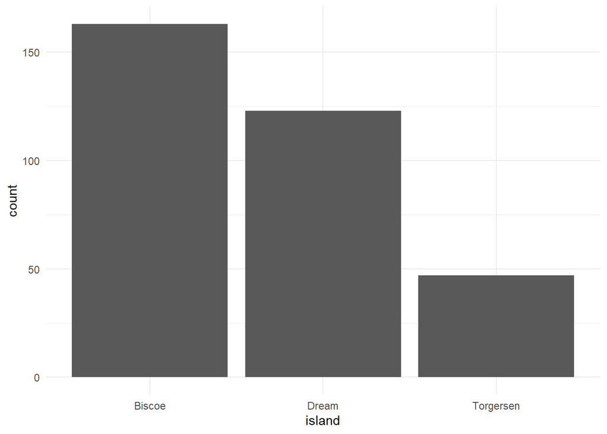

```r
ggplot(penguins, aes(x=island)) +
geom_bar() +
theme_minimal()
```

#### Q2 answer: The shape is bimodal. At 10 bins, the peaks can merge and details could get hidden. 30 bins have more detail. 60 bins can show smaller variations. Adding facet_wrap will have each of the distributions have different approximates means. The distribution differs because Adelie is shifted more left, Gentoo is shifted more right, and Chinstrap is in-between.

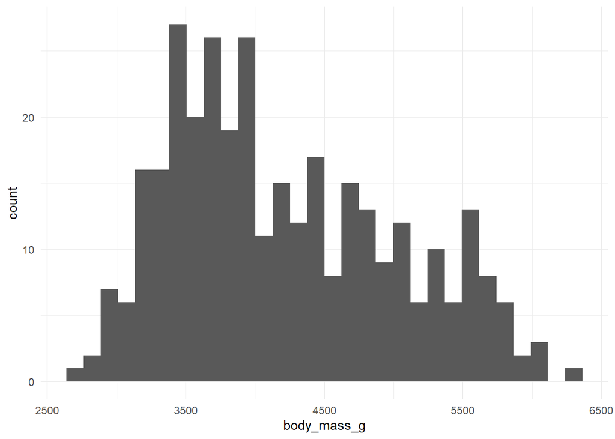

```r
ggplot(penguins, aes(x = body_mass_g)) +
  geom_histogram(bins = 30) +
  theme_minimal()
```

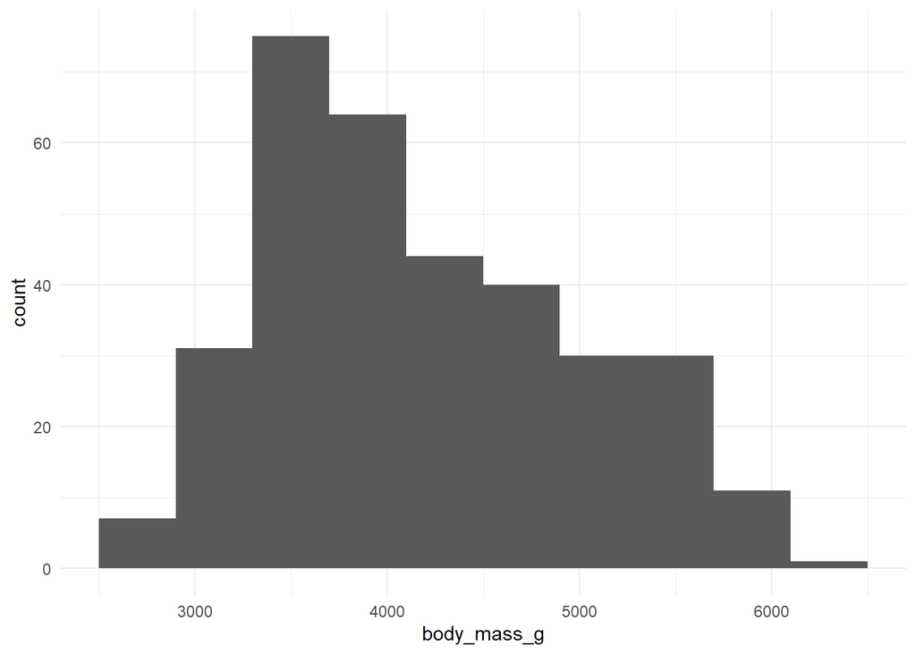

```r
ggplot(penguins, aes(x = body_mass_g)) +
  geom_histogram(bins = 10) +
  theme_minimal()
```

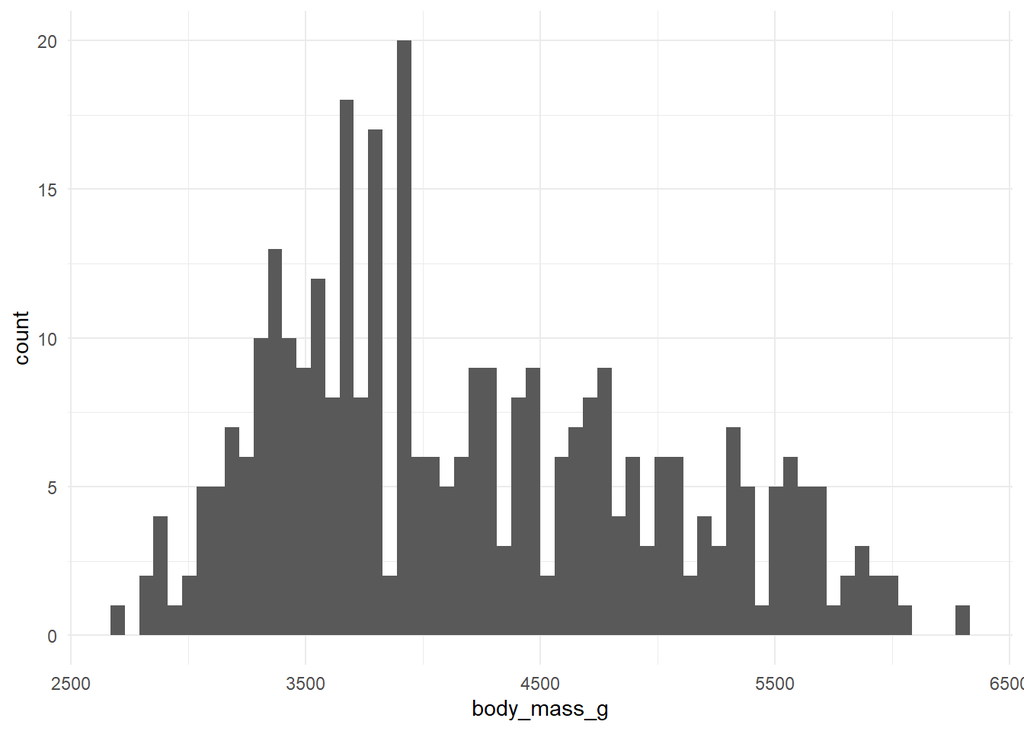

```r
ggplot(penguins, aes(x = body_mass_g)) +
  geom_histogram(bins = 60) +
  theme_minimal()
```

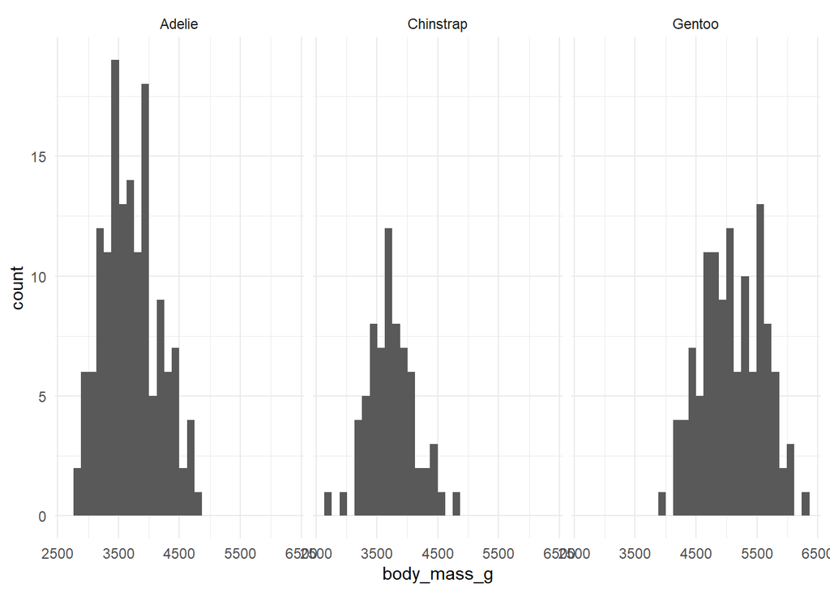

```r
ggplot(penguins, aes(x = body_mass_g)) +
  geom_histogram(bins = 30) +
  facet_wrap(~ species) +
  theme_minimal()
```

#### Q3 answer: Gentoo has the highest median and typical flipper length. Males and females differ. Males are heavier. Adding fill = species makes the plot easier to read by adding colors and filling the boxes with them.

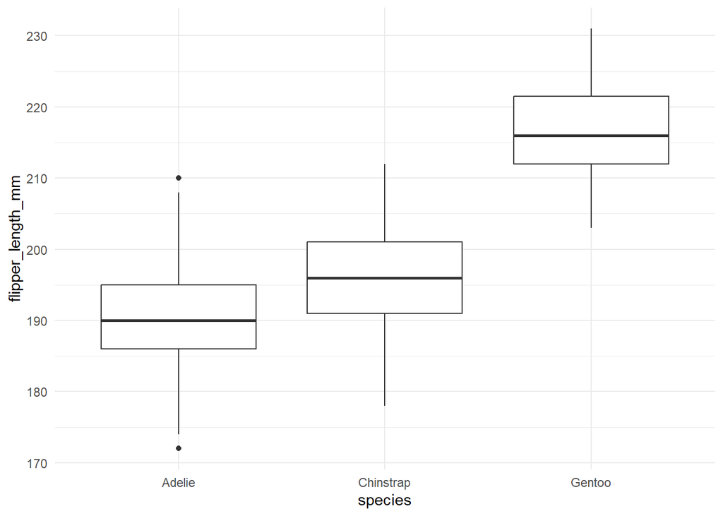

```r
ggplot(penguins, aes(x = species, y = flipper_length_mm)) +
  geom_boxplot() +
  theme_minimal()
```

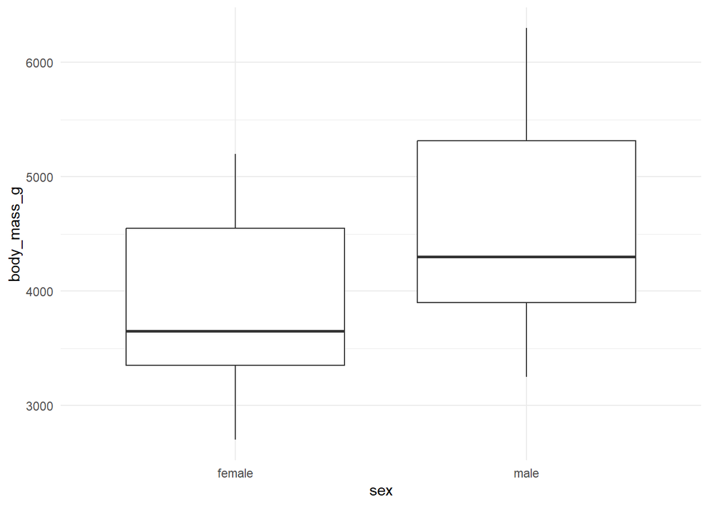

```r
ggplot(penguins, aes(x = sex, y = body_mass_g)) +
  geom_boxplot() +
  theme_minimal()
```

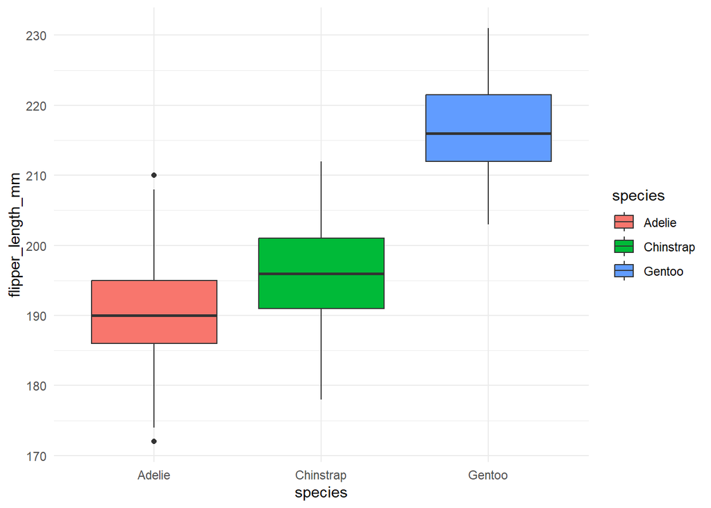

```r
ggplot(penguins, aes(x = species, y = flipper_length_mm, fill = species)) +
  geom_boxplot() +
  theme_minimal()
```

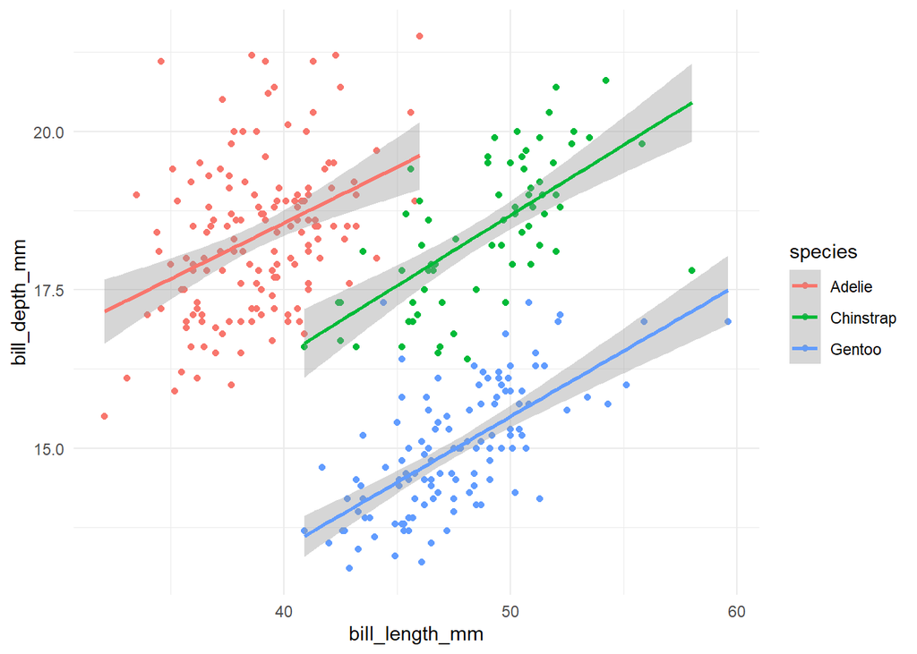

```r
ggplot(penguins, aes(x = bill_length_mm, y = bill_depth_mm, color = species)) +
  geom_point() +
  geom_smooth(method = "lm") +
  theme_minimal()
```

#### Q5 answer: Gentoo shows the strongest relationship and has a very clear upward linear trend compared with other species. For the plot that used facet_grid, there were six seperate lines that were all positively correlated between body_mass_mm and flipper_length_mm

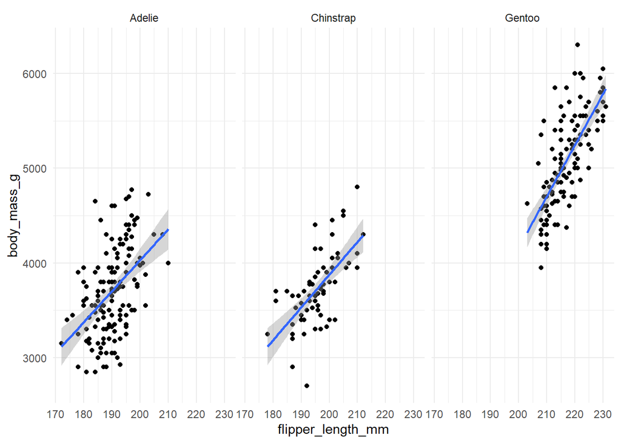

```r
ggplot(penguins, aes(x = flipper_length_mm, y = body_mass_g)) +
  geom_point() +
  geom_smooth(method = "lm") +
    facet_wrap(~ species) +
  theme_minimal()
```

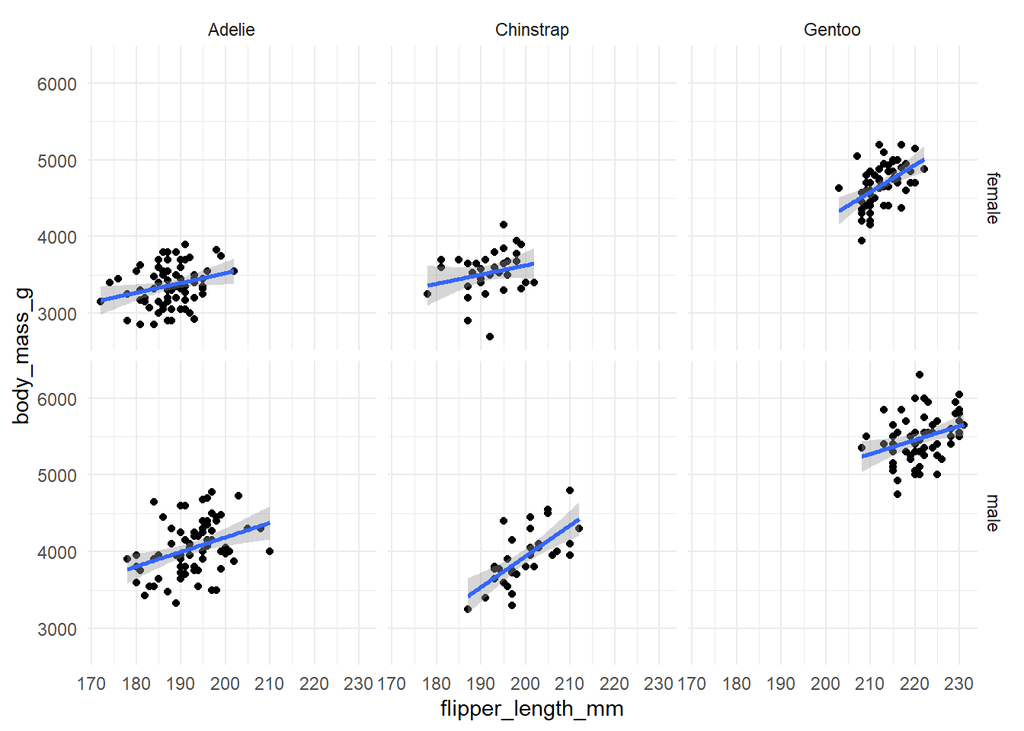

```r
ggplot(penguins, aes(x = flipper_length_mm, y = body_mass_g)) +
  geom_point() +
  geom_smooth(method = "lm") +
  facet_grid(sex ~ species) +
  theme_minimal()
```

#### Q6

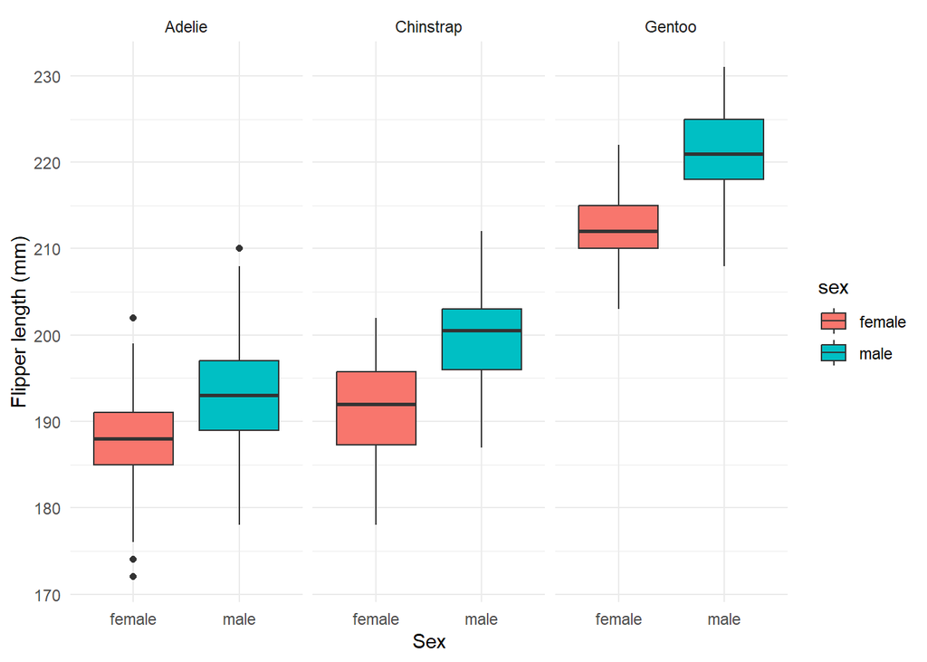

```r
penguins <- penguins %>%
  drop_na(flipper_length_mm, body_mass_g, bill_length_mm, bill_depth_mm, sex)
ggplot(penguins, aes(x = sex, y = flipper_length_mm, fill = sex)) +
  geom_boxplot() +
  facet_wrap(~ species) +
  labs(x = "Sex",
       y = "Flipper length (mm)"
       ) +
  theme_minimal()
```

#### Q7 The best part of the exercise was being able to make my own graph. I made a boxplot and used sex, just like question 3. But also, trying out different themes was interesting and learning how to make the plots a specific color. The most difficult part was that I didn’t realize what the difference between facet_wrap was and facet_grid was. This resulted in me getting a bunch of errors and the graph not working.

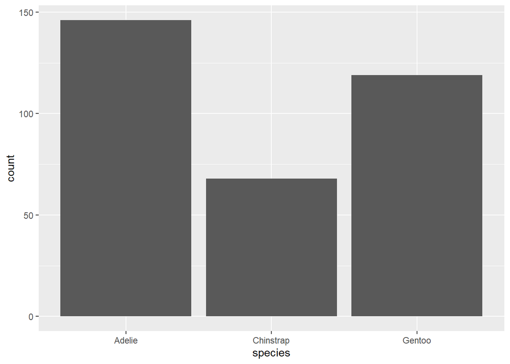

```r
ggplot(penguins, aes(x = species))+
geom_bar()
```

```r
penguins_messy <- read.csv("penguins_messy.csv")
```

# Lecture 07

#### Q1 answers: The code with penguins_messy$species_messy, looks at the species_messy column and checks if the text contains the string "adelie". It returns TRUE if "adelie" is found and FALSE if it's not. The code with penguins_messy$sex_messy looks at the sex_messy column and replaces all the ? with ““. The code with penguins_messy$isalnd_messy looks at the island_messy column and replaces all the multiple spaces with a single space.

```r
str_detect(penguins_messy$species_messy, "adelie")
```

```
##   [1]  TRUE  TRUE  TRUE  TRUE  TRUE  TRUE  TRUE  TRUE  TRUE  TRUE  TRUE  TRUE
##  [13]  TRUE  TRUE  TRUE  TRUE  TRUE  TRUE  TRUE  TRUE  TRUE  TRUE  TRUE  TRUE
##  [25]  TRUE  TRUE  TRUE  TRUE  TRUE  TRUE  TRUE  TRUE  TRUE  TRUE  TRUE  TRUE
##  [37]  TRUE  TRUE  TRUE  TRUE  TRUE  TRUE  TRUE  TRUE  TRUE  TRUE  TRUE  TRUE
##  [49]  TRUE  TRUE  TRUE  TRUE  TRUE  TRUE  TRUE  TRUE  TRUE  TRUE  TRUE  TRUE
##  [61]  TRUE  TRUE  TRUE  TRUE  TRUE  TRUE  TRUE  TRUE  TRUE  TRUE  TRUE  TRUE
##  [73]  TRUE  TRUE  TRUE  TRUE  TRUE  TRUE  TRUE  TRUE  TRUE  TRUE  TRUE  TRUE
##  [85]  TRUE  TRUE  TRUE  TRUE  TRUE  TRUE  TRUE  TRUE  TRUE  TRUE  TRUE  TRUE
##  [97]  TRUE  TRUE  TRUE  TRUE  TRUE  TRUE  TRUE  TRUE  TRUE  TRUE  TRUE  TRUE
## [109]  TRUE  TRUE  TRUE  TRUE  TRUE  TRUE  TRUE  TRUE  TRUE  TRUE  TRUE  TRUE
## [121]  TRUE  TRUE  TRUE  TRUE  TRUE  TRUE  TRUE  TRUE  TRUE  TRUE  TRUE  TRUE
## [133]  TRUE  TRUE  TRUE  TRUE  TRUE  TRUE  TRUE  TRUE  TRUE  TRUE  TRUE  TRUE
## [145]  TRUE  TRUE  TRUE  TRUE  TRUE  TRUE  TRUE  TRUE FALSE FALSE FALSE FALSE
## [157] FALSE FALSE FALSE FALSE FALSE FALSE FALSE FALSE FALSE FALSE FALSE FALSE
## [169] FALSE FALSE FALSE FALSE FALSE FALSE FALSE FALSE FALSE FALSE FALSE FALSE
## [181] FALSE FALSE FALSE FALSE FALSE FALSE FALSE FALSE FALSE FALSE FALSE FALSE
## [193] FALSE FALSE FALSE FALSE FALSE FALSE FALSE FALSE FALSE FALSE FALSE FALSE
## [205] FALSE FALSE FALSE FALSE FALSE FALSE FALSE FALSE FALSE FALSE FALSE FALSE
## [217] FALSE FALSE FALSE FALSE FALSE FALSE FALSE FALSE FALSE FALSE FALSE FALSE
## [229] FALSE FALSE FALSE FALSE FALSE FALSE FALSE FALSE FALSE FALSE FALSE FALSE
## [241] FALSE FALSE FALSE FALSE FALSE FALSE FALSE FALSE FALSE FALSE FALSE FALSE
## [253] FALSE FALSE FALSE FALSE FALSE FALSE FALSE FALSE FALSE FALSE FALSE FALSE
## [265] FALSE FALSE FALSE FALSE FALSE FALSE FALSE FALSE FALSE FALSE FALSE FALSE
## [277] FALSE FALSE FALSE FALSE FALSE FALSE FALSE FALSE FALSE FALSE FALSE FALSE
## [289] FALSE FALSE FALSE FALSE FALSE FALSE FALSE FALSE FALSE FALSE FALSE FALSE
## [301] FALSE FALSE FALSE FALSE FALSE FALSE FALSE FALSE FALSE FALSE FALSE FALSE
## [313] FALSE FALSE FALSE FALSE FALSE FALSE FALSE FALSE FALSE FALSE FALSE FALSE
## [325] FALSE FALSE FALSE FALSE FALSE FALSE FALSE FALSE FALSE FALSE FALSE FALSE
## [337] FALSE FALSE FALSE FALSE FALSE FALSE FALSE FALSE
```

```r
str_replace_all(penguins_messy$sex_messy, "\\?", "")
```

```
##   [1] "M" "f" "f" NA  "f" "M" "f" "M" NA  NA  NA  NA  "f" "M" "M" "f" "f" "M"
##  [19] "f" "M" "f" "M" "f" "M" "M" "f" "M" "f" "f" "M" "f" "M" "f" "M" "f" "M"
##  [37] "M" "f" "f" "M" "f" "M" "f" "M" "f" "M" "M" NA  "f" "M" "f" "M" "f" "M"
##  [55] "f" "M" "f" "M" "f" "M" "f" "M" "f" "M" "f" "M" "f" "M" "f" "M" "f" "M"
##  [73] "f" "M" "f" "M" "f" "M" "f" "M" "f" "M" "f" "M" "f" "M" "M" "f" "M" "f"
##  [91] "f" "M" "f" "M" "f" "M" "f" "M" "f" "M" "f" "M" "f" "M" "f" "M" "f" "M"
## [109] "f" "M" "f" "M" "f" "M" "f" "M" "f" "M" "f" "M" "f" "M" "f" "M" "f" "M"
## [127] "f" "M" "f" "M" "f" "M" "f" "M" "f" "M" "f" "M" "f" "M" "f" "M" "f" "M"
## [145] "f" "M" "M" "f" "f" "M" "f" "M" "f" "M" "f" "M" "M" "f" "f" "M" "f" "M"
## [163] "f" "M" "f" "M" "f" "M" "f" "M" "f" "M" "M" "f" "f" "M" "f" "M" NA  "M"
## [181] "f" "M" "M" "f" "f" "M" "f" "M" "f" "M" "f" "M" "f" "M" "f" "M" "M" "f"
## [199] "f" "M" "f" "M" "f" "M" "f" "M" "f" "M" "f" "M" "f" "M" "f" "M" "f" "M"
## [217] "f" "M" NA  "M" "f" "M" "f" "M" "M" "f" "f" "M" "f" "M" "f" "M" "f" "M"
## [235] "f" "M" "f" "M" "f" "M" "f" "M" "f" "M" "f" "M" "f" "M" "M" "f" "f" "M"
## [253] "f" "M" "f" "M" NA  "M" "f" "M" "f" "M" "f" "M" "f" "M" "f" "M" NA  "M"
## [271] "f" NA  "f" "M" "f" "M" "f" "M" "M" "f" "M" "f" "f" "M" "f" "M" "f" "M"
## [289] "f" "M" "f" "M" "M" "f" "f" "M" "f" "M" "f" "M" "f" "M" "f" "M" "f" "M"
## [307] "f" "M" "f" "M" "M" "f" "f" "M" "f" "M" "M" "f" "M" "f" "f" "M" "f" "M"
## [325] "M" "f" "f" "M" "f" "M" "f" "M" "f" "M" "M" "f" "M" "f" "f" "M" "f" "M"
## [343] "M" "f"
```

```r
str_squish(penguins_messy$island_messy)
```

```
##   [1] "Torgersen" "Torgersen" "Torgersen" "Torgersen" "Torgersen" "Torgersen"
##   [7] "Torgersen" "Torgersen" "Torgersen" "Torgersen" "Torgersen" "Torgersen"
##  [13] "Torgersen" "Torgersen" "Torgersen" "Torgersen" "Torgersen" "Torgersen"
##  [19] "Torgersen" "Torgersen" "BIS-COE"   "BIS-COE"   "BIS-COE"   "BIS-COE"
##  [25] "BIS-COE"   "BIS-COE"   "BIS-COE"   "BIS-COE"   "BIS-COE"   "BIS-COE"
##  [31] "Dream"     "Dream"     "Dream"     "Dream"     "Dream"     "Dream"
##  [37] "Dream"     "Dream"     "Dream"     "Dream"     "Dream"     "Dream"
##  [43] "Dream"     "Dream"     "Dream"     "Dream"     "Dream"     "Dream"
##  [49] "Dream"     "Dream"     "BIS-COE"   "BIS-COE"   "BIS-COE"   "BIS-COE"
##  [55] "BIS-COE"   "BIS-COE"   "BIS-COE"   "BIS-COE"   "BIS-COE"   "BIS-COE"
##  [61] "BIS-COE"   "BIS-COE"   "BIS-COE"   "BIS-COE"   "BIS-COE"   "BIS-COE"
##  [67] "BIS-COE"   "BIS-COE"   "Torgersen" "Torgersen" "Torgersen" "Torgersen"
##  [73] "Torgersen" "Torgersen" "Torgersen" "Torgersen" "Torgersen" "Torgersen"
##  [79] "Torgersen" "Torgersen" "Torgersen" "Torgersen" "Torgersen" "Torgersen"
##  [85] "Dream"     "Dream"     "Dream"     "Dream"     "Dream"     "Dream"
```

[output cut: 43 more lines]

#### Q2 answers: The number was 316.

```r
penguins_messy <- penguins_messy %>%
    mutate(valid_id = str_detect(sample_id, "PAL-[0-9]{3}"))
penguins_messy %>% pull(valid_id) %>% sum
```

```
## [1] 316
```

#### Q3

```r
penguins_messy <- penguins_messy %>%
  filter(valid_id == TRUE)
```

#### Q4

```r
penguins_messy <- penguins_messy %>%
  mutate(
    file_date = str_extract(file_name, "^[0-9]{4}-[0-9]{2}-[0-9]{2}"),
    file_id = str_extract(file_name, "PAL-[0-9]{3}")
  )

head(penguins_messy$file_date, 10)
```

```
##  [1] "2024-01-14" "2024-01-17" "2024-01-08" "2024-01-26" "2024-01-06"
##  [6] "2024-01-08" "2024-01-08" "2024-01-19" "2024-01-14" "2024-01-24"
```

```r
head(penguins_messy$file_id, 10)
```

```
##  [1] "PAL-535" "PAL-442" "PAL-668" "PAL-920" "PAL-223" "PAL-899" "PAL-268"
##  [8] "PAL-139" "PAL-847" "PAL-238"
```

#### Q5

```r
penguins_messy <- penguins_messy %>%
  mutate(island = str_squish(island_messy))

unique(penguins_messy$island)
```

```
## [1] "Torgersen" "BIS-COE"   "Dream"
```

#### Q6

```r
penguins_messy <- penguins_messy %>%
  mutate(
    sex = sex_messy %>%
      str_replace_all("\\?", "") %>%
      str_to_upper()
  )
unique(penguins_messy$sex)
```

```
## [1] "M" "F" NA
```

#### Q7

```r
penguins_messy <- penguins_messy %>%
  mutate(
    bill_mm = notes %>%
      str_replace_all("(.*bill=)|mm", "") %>%
      as.numeric()
  )
```

#### Q8 answer: This lesson was signficantly harder than the previous lessons since it doesn’t really tell you everything you need to do to complete the code. The most interesting part of this exercise was the str_replace_all function because we learned how to remove a question mark and repalce with nothing. I have a general idea of how regular expressions are used.

# Lecture 08

```r
original_row <- nrow(penguins)
print(original_row)
```

```
## [1] 333
```

```r
penguins_clean <- penguins %>%
  drop_na(bill_length_mm, sex)

cleaned_penguins <- nrow(penguins_clean)
print(cleaned_penguins)
```

```
## [1] 333
```

#### Q2 answer: Duplicates can mess up observations because they can inflate the sample size. They will also shift the mean or median when you try to make a graph and create different types of distributions.

```r
penguins_dup <- penguins_clean %>%
  bind_rows(slice_sample(penguins_clean, n = 30, replace = TRUE))
nrow(penguins_dup)
```

```
## [1] 363
```

```r
penguins_dup %>% distinct() %>% nrow()
```

```
## [1] 333
```

#### Q3 answer: There are 8 columns.

```r
penguino <- penguins_clean %>%
  select(species, sex, island, where(is.numeric))
  ncol(penguino)
```

```
## [1] 8
```

#### Q4 answer:

```r
penguins_clean %>%
  select(starts_with("bill"))
```

```
## # A tibble: 333 × 2
##    bill_length_mm bill_depth_mm
##             <dbl>         <dbl>
##  1           39.1          18.7
##  2           39.5          17.4
##  3           40.3          18
##  4           36.7          19.3
##  5           39.3          20.6
##  6           38.9          17.8
##  7           39.2          19.6
##  8           41.1          17.6
##  9           38.6          21.2
## 10           34.6          21.1
## # ℹ 323 more rows
```

```r
penguins_clean %>%
  select(ends_with("_mm"))
```

```
## # A tibble: 333 × 3
##    bill_length_mm bill_depth_mm flipper_length_mm
##             <dbl>         <dbl>             <int>
##  1           39.1          18.7               181
##  2           39.5          17.4               186
##  3           40.3          18                 195
##  4           36.7          19.3               193
##  5           39.3          20.6               190
##  6           38.9          17.8               181
##  7           39.2          19.6               195
##  8           41.1          17.6               182
##  9           38.6          21.2               191
## 10           34.6          21.1               198
## # ℹ 323 more rows
```

```r
penguins_clean %>%
  select(matches("(bill|flipper)"))
```

```
## # A tibble: 333 × 3
##    bill_length_mm bill_depth_mm flipper_length_mm
##             <dbl>         <dbl>             <int>
##  1           39.1          18.7               181
##  2           39.5          17.4               186
##  3           40.3          18                 195
##  4           36.7          19.3               193
##  5           39.3          20.6               190
##  6           38.9          17.8               181
##  7           39.2          19.6               195
##  8           41.1          17.6               182
##  9           38.6          21.2               191
## 10           34.6          21.1               198
## # ℹ 323 more rows
```

#### Q5 answer: Using across allows you to apply the function to all the columns with numeric values. You don’t need to manually list the columns.

```r
penguins_clean %>%
  group_by(species) %>%
  summarize(across(where(is.numeric), mean))
```

```
## # A tibble: 3 × 6
##   species   bill_length_mm bill_depth_mm flipper_length_mm body_mass_g  year
##   <fct>              <dbl>         <dbl>             <dbl>       <dbl> <dbl>
## 1 Adelie              38.8          18.3              190.       3706. 2008.
## 2 Chinstrap           48.8          18.4              196.       3733. 2008.
## 3 Gentoo              47.6          15.0              217.       5092. 2008.
```

#### Q6

```r
penguins_clean <- penguins_clean %>%
  mutate(
    bill_length = case_when(
      bill_length_mm < 40 ~ "short",
      bill_length_mm < 50 ~ "medium",
      bill_length_mm >= 50 ~ "long"
    )
  )
```

#### Q7 answer: There are 9 columns in penguins_clean and 12 columns in penguins_instrumented.

```r
instrument_meta <- tibble(
  instrument_id = c("caliper_A", "caliper_B", "caliper_C"),
  calibration_mm = c(0.2, 0.5, 1.0),
  manufacturer = c("Mitutoyo", "Fowler", "Generic")
)
penguins_instrumented <- penguins_clean %>%
  drop_na(bill_length_mm) %>%
  mutate(
    instrument_id = case_when(
      year == 2007 ~ "caliper_A",
      year == 2008 ~ "caliper_B",
      year == 2009 ~ "caliper_C"
    )
  ) %>%
left_join(instrument_meta, penguins_instrumented, by = "instrument_id")

ncol(penguins_clean)
```

```
## [1] 9
```

```r
ncol(penguins_instrumented)
```

```
## [1] 12
```

#### Q8 answer: The most fun part of this exercise was putting all the stuff we learned from the chapters together to make the new data frame. It was also the most difficult to do because there was so much that could go wrong and it was a longer code I had to write. I forgot to pipe at times. These survival tips can be useful for future data analyses in the future. I research fish and will probably need to remove or add unavailable data depending on which fish died and is alive.